# Recommendation System

Alena Suvorova

22 05 2017

Сегодня мы рассмотрим пример построения небольшой рекомендательной системы в R. Используем пакет `recommenderlab` https://cran.r-project.org/web/packages/recommenderlab/vignettes/recommenderlab.pdf

### Загрузка данных

Работаем с данными Amazon о фильмах

```r
library(jsonlite)
library(stringr)
library(dplyr)
library(readr)
```

Чтение и преобразование данных (см. предыдущую лабораторную)

```r
j = read_lines("~/shared/minor2_2016/data/amazon/reviews_Movies_and_TV_5_sub48.json") %>%
  str_c(collapse = ",") %>%
  (function(str) str_c("[", str, "]")) %>%
  fromJSON(simplifyDataFrame = T)

jmeta = readLines("~/shared/minor2_2016/data/amazon/meta_Movies_and_TV_5_sub48.json") %>%
  str_c(collapse = ",") %>%
  (function(str) str_c("[", str, "]")) %>%
  fromJSON(simplifyDataFrame = T)
```

Возьмем из мета-информации только заголовки, цену и описание и уберем комментарии в скобках в заголовках

```r
jmeta = select(jmeta, title, asin, price, description)
jmeta$title = str_replace_all(jmeta$title, "\\(.*\\)", "")
jmeta$title = str_replace_all(jmeta$title, "\\[.*\\]", "")
```

Присоединим заголовки к основному датасету

```r
j = left_join(j, jmeta, by = "asin")
```

### Оценки фильмов пользователями

Сохраним только оценки пользователей и фильмы

```r
rates = select(j, reviewerID, asin, overall)
```

Преобразуем к таблице в “широком” формате

```r
library(tidyr)
rates = spread(rates, key = asin, value = overall)
```

Для дальнейшей работы в данных должны остаться только оценки, поэтому переведим сначала пользователей в имена строк

```r
rownames(rates) = rates$reviewerID
rates = select(rates, -reviewerID)
```

Начинаем работать с пакетом `recommenderlab`

```r
library(recommenderlab)
```

Преобразуем данные с оценками в тот формат, который “понимает” этот пакет. Таких форматов несколько, нас интересует тот, где используются численные оценки (не бинарные, а с большим числом значений) – realRatingMatrix

```r
rates = as.matrix(rates)
r = as(rates, "realRatingMatrix")
r
```

```
## 376 x 500 rating matrix of class 'realRatingMatrix' with 4303 ratings.
```

Каждая строчка соответствует пользователю, столбец – фильму, на пересечении – оценки. Однако в полной матрице 376*500 было бы слишком много пропущенных значений (каждый пользователь оценивает существенно меньше фильмов, чем есть в датасете). Поэтому используется более компактный способ хранения.

*Обратите внимание* – датасет хранится в объекте класса realRatingMatrix, а не data.frame или matrix. Поэтому есть особенности работы с такими данными, например, ряд специальных функций именно для рекомендательных систем.

```r
rowMeans(r)
```

```
## A104IDA5ZI6PT6 A10BCTTKD65EZV A10FIX216EST0J A10HHM2684NZD2 A10ODC971MDHV8
##       5.000000       5.000000       3.000000       3.222222       5.000000
## A10SR0OBXLYYA2  A10YJJ1J98XPT A12N96M5CIJY90 A137AX2DG2D3QD A13E0ARAXI6KJW
##       5.000000       3.000000       5.000000       3.000000       3.854167
## A13Q73QFDEBO1N A13Z3RD1MKC0HB A143P0NKQDNWYL A146D2LYLICNLS A14SFXB2HEDXU1
##       5.000000       4.750000       3.909091       3.333333       5.000000
## A1534MBU6VJXYN A167CL1OHIBCNR A16A23O0UEKPCF A16CZRQL23NOIW A16R4IYSKRBSAK
##       4.882353       5.000000       2.500000       4.658333       4.000000
## A178D7UPKLU2DP A17FLA8HQOFVIG A17HIZVCAYJVQ9 A18758S1PUYIDT A191ZD1RVWT476
##       1.000000       4.258621       4.000000       3.944444       5.000000
## A194VJZC0N3KWX A19FOCXJ5OSIOE A1A2JF42QO287Y A1A4R6PU3QYVJ5 A1AISPOIIHTHXX
##       5.000000       5.000000       2.000000       3.000000       4.262295
##  A1ALVTBS2UO10 A1AMOI4ZJ2PCI7 A1AZL7ZPQDVHU7 A1B1B68XXFLUGC  A1B2IZU1JLZA6
##       5.000000       5.000000       3.000000       5.000000       1.000000
## A1B6QFRKM2EX25 A1BCVPSEZ5NSXK A1BQJINQGJTAE9 A1CK4J7YRAUQ53 A1CYOHNGQ1WED1
##       4.000000       4.333333       1.000000       5.000000       2.800000
## A1DRM3JV6T5O6P A1DZKOOMMJM1MI A1EAFFJQ2NDHGC A1EOEYW5SMC6CV A1EXVX5DJ7YJP3
##       4.500000       4.111111       3.333333       4.000000       3.333333
## A1EYS0SF2CWUQJ A1FCWRSICTO2AH A1FYUCCC8CX1E0 A1G1BKRT12DIKB A1GBMUSQ1GN9QH
##       5.000000       3.500000       4.600000       1.666667       4.000000
## A1GHO6BR5J0NHX A1GLYYFZG2W6P7 A1J03J0HZ7KU5T A1J5TC13BSPA2M A1JXE27STRRE0H
##       2.000000       3.800000       3.406250       4.750000       3.750000
## A1K3NQAO49LXL2 A1KISYZSUGHL5P A1L8HRCM60W0W7 A1LDAIGOQ6N4DW A1LOT93D6QXZ0X
##       4.454545       2.800000       3.636364       4.857143       4.333333
## A1LVZOK9F7K4CN A1LZVU5SRRM3VX A1MD6MXBHCRC0V A1MIFU0YKLG40T A1N7YA81ZI4KAF
##       3.956522       3.444444       5.000000       5.000000       3.666667
## A1NSMQIF1C2VCE A1NV8HZTGKIPXQ  A1OKKON69AHLR A1OL82DFRN9G4J A1P703Y7O9WEP1
##       3.785714       3.750000       1.000000       5.000000       2.800000
##  A1PASRZ81DY9C A1PAXY1NXBJQ7C A1PCURH987OBMJ A1PIGCPED659KW A1PW6G3EFXCLFJ
##       3.410714       5.000000       5.000000       4.000000       2.333333
## A1RP6YCOS5VJ5I A1RV3ITFIDCKI6 A1SAMSDY8108OH A1SDD9CRA4S9U0 A1STKLM29PSOQ2
##       4.288889       5.000000       4.000000       5.000000       5.000000
## A1TO1P3NV7OAU6 A1TPBMY2JWHAMK A1TTD2GS7O4IDA A1TW9ZGRDQQZ2Y A1UFARU1PZAX6V
##       4.560000       5.000000       5.000000       4.352941       2.666667
## A1UFY2YWV81UZB A1UJ1IPLM7B1I9 A1V3TRGWOMA8LC A1W45KBJFUTHFM A1W4XYOCNRADCO
##       4.750000       5.000000       4.500000       5.000000       5.000000
## A1W5NAAE1ERLP0 A1WIZ78S4T2AP2 A1WT8IK8L6GYQJ   A1X054KUYG5V A1YCW7P7M44W4T
##       2.000000       4.500000       5.000000       3.423077       3.000000
## A1YIWDKM1292L4  A1YJQ0I05KU3M A1YZ9CA3NW99C0 A1ZKVLM2E00KNU A1ZWZYP4O0VJMU
##       3.666667       3.000000       5.000000       2.333333       1.000000
```

[output cut: 97 more lines]

```
##       2.000000       5.000000       3.000000       4.476190       2.375000
##  AQP1VPK16SVWM  AQZH7YTWQPOBE  ASYN7RG93QPAY  AT1GMH2UHYROT  ATET913EWNUD0
##       4.129870       4.227273       5.000000       5.000000       5.000000
##  AUCISQA1YXX86  AUTBHG6070SL4  AUUTZCLQCVDK3  AUZ460FTPQRNQ  AVPM4HFPBHGFK
##       2.428571       3.944444       5.000000       4.000000       2.000000
##  AVRAHBLJC79JQ  AVZ4T60UVJ3MM  AW2QSBNKZKSNT  AW99SBGWEXP0J  AX37GMKEEQNDQ
##       5.000000       5.000000       5.000000       3.957447       5.000000
##  AX5AA7VI3KIAH  AXF3ZAXUGOEON  AXKLJRDTPJCA7  AXO4PQU0XG3TG  AXQ2R2VLV98QY
##       4.666667       4.000000       3.166667       3.600000       5.000000
##  AY69ZK7G6CNYJ  AYF76HQ10BL2J  AYQF4Z1EQDACU  AYWAY5MKLAITN  AYWSFRCIMOAYE
##       4.647059       4.000000       3.937500       4.157895       2.545455
##  AZ1YLZGNDS40I  AZCDCO6KK2T81  AZLC3D46UHOAK  AZMX1PT81RGCG  AZTDHDUTVOSCC
##       4.000000       4.093750       5.000000       5.000000       3.500000
##  AZV2Y78FIJSU6
##       5.000000
```

### Похожесть по оценкам

Похожесть (similarity) может определяться разными способами

- Коэффициент Пирсона;
- Косинусное расстояние;
- Евклидово расстояние.

Рассмотрим, например, похожесть первых 10 пользователей

```r
similarity_users10 <- similarity(r[1:10, ], method = "cosine", which = "users")
as.matrix(similarity_users10)
```

```
##                A104IDA5ZI6PT6 A10BCTTKD65EZV A10FIX216EST0J A10HHM2684NZD2
## A104IDA5ZI6PT6              0             NA             NA             NA
## A10BCTTKD65EZV             NA              0             NA             NA
## A10FIX216EST0J             NA             NA              0             NA
## A10HHM2684NZD2             NA             NA             NA     0.00000000
## A10ODC971MDHV8             NA             NA             NA     0.07408756
## A10SR0OBXLYYA2             NA             NA             NA     0.05431254
## A10YJJ1J98XPT              NA             NA             NA             NA
## A12N96M5CIJY90             NA             NA             NA             NA
## A137AX2DG2D3QD             NA             NA             NA             NA
## A13E0ARAXI6KJW             NA             NA             NA     0.17709319
##                A10ODC971MDHV8 A10SR0OBXLYYA2 A10YJJ1J98XPT A12N96M5CIJY90
## A104IDA5ZI6PT6             NA             NA            NA             NA
## A10BCTTKD65EZV             NA             NA            NA             NA
## A10FIX216EST0J             NA             NA            NA             NA
## A10HHM2684NZD2     0.07408756     0.05431254            NA             NA
## A10ODC971MDHV8     0.00000000             NA            NA             NA
## A10SR0OBXLYYA2             NA     0.00000000            NA             NA
## A10YJJ1J98XPT              NA             NA     0.0000000             NA
## A12N96M5CIJY90             NA             NA            NA              0
## A137AX2DG2D3QD             NA             NA            NA             NA
## A13E0ARAXI6KJW     0.19143531     0.10450742     0.1619022             NA
##                A137AX2DG2D3QD A13E0ARAXI6KJW
## A104IDA5ZI6PT6             NA             NA
## A10BCTTKD65EZV             NA             NA
## A10FIX216EST0J             NA             NA
## A10HHM2684NZD2             NA      0.1770932
## A10ODC971MDHV8             NA      0.1914353
## A10SR0OBXLYYA2             NA      0.1045074
## A10YJJ1J98XPT              NA      0.1619022
## A12N96M5CIJY90             NA             NA
## A137AX2DG2D3QD      0.0000000      0.1344525
## A13E0ARAXI6KJW      0.1344525      0.0000000
```

Или в виде графика (heatmap)

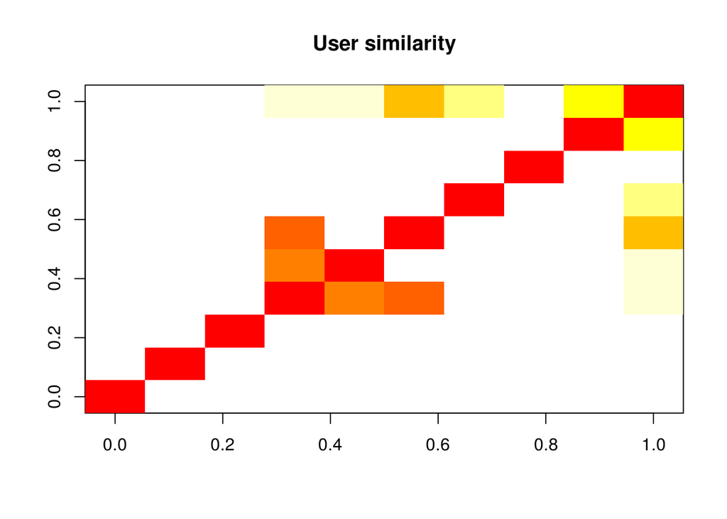

```r
image(as.matrix(similarity_users10), main = "User similarity")
```

Таким же образом можно посчитать и схожесть между фильмами

### Предварительная подготовка данных

Сначала подготовим данные, в частности, уберем те, что являются нерелевантными.

Если фильм редкий, его мало кто видел, то оценки для него могут быть сильно смещенными. Так же и для пользователя – если он оценил малое число фильмов, то ему сложно дать рекомендацию.

Как определить, что является “малым числом”? В общем случае – итерационно, т.е. отбираем данные, строим модель, оцениваем ее и так несколько раз. В данном примере рассмотрим только один шаг – будем считать, что нас интересуют фильмы с не менее 10 оценками и пользователи, поставившие не менее 5 оценок.

Количество оценок у фильма можно посчитать с помощью функции colCounts(), а количество оценок, поставленных одним пользователем – с помощью rowCounts().

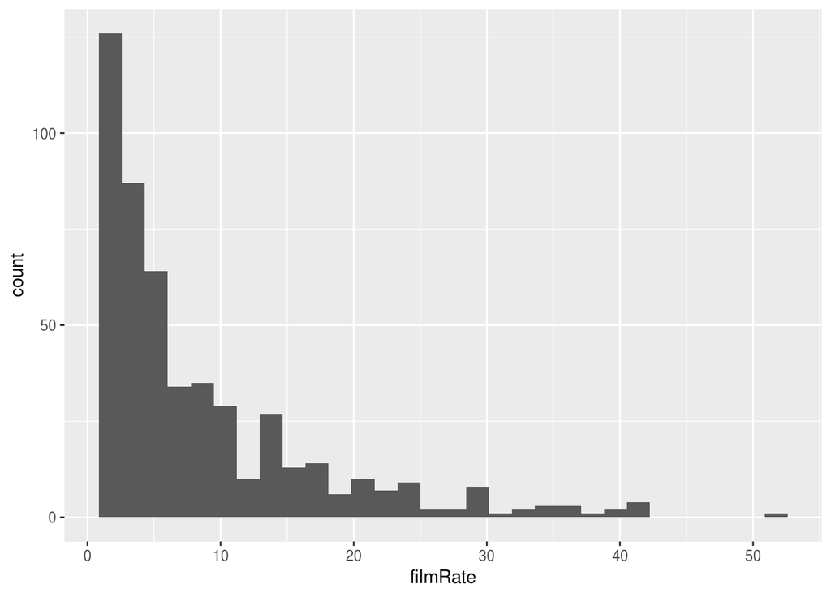

```r
library(ggplot2)
ggplot(data = data.frame(filmRate=colCounts(r))) + geom_histogram(aes(x=filmRate))
```

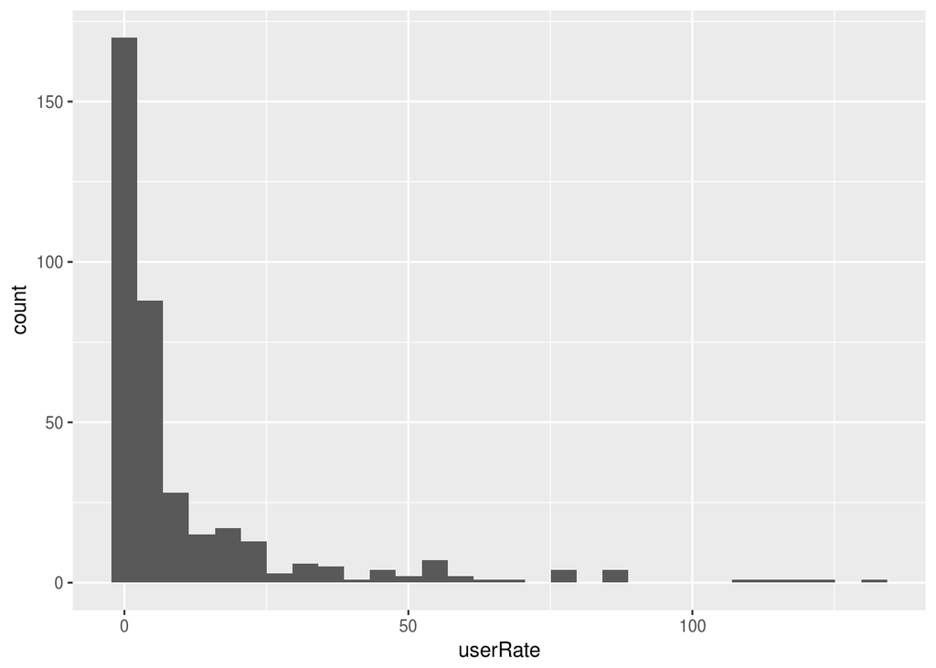

```r
ggplot(data = data.frame(userRate=rowCounts(r))) + geom_histogram(aes(x=userRate))
```

Отберем только строки и столбцы с нужным количеством оценок

```r
ratings_movies <- r[rowCounts(r) > 5, colCounts(r) > 10]
ratings_movies
```

```
## 128 x 139 rating matrix of class 'realRatingMatrix' with 2394 ratings.
```

Рассмотрим распределение средних оценок пользователя

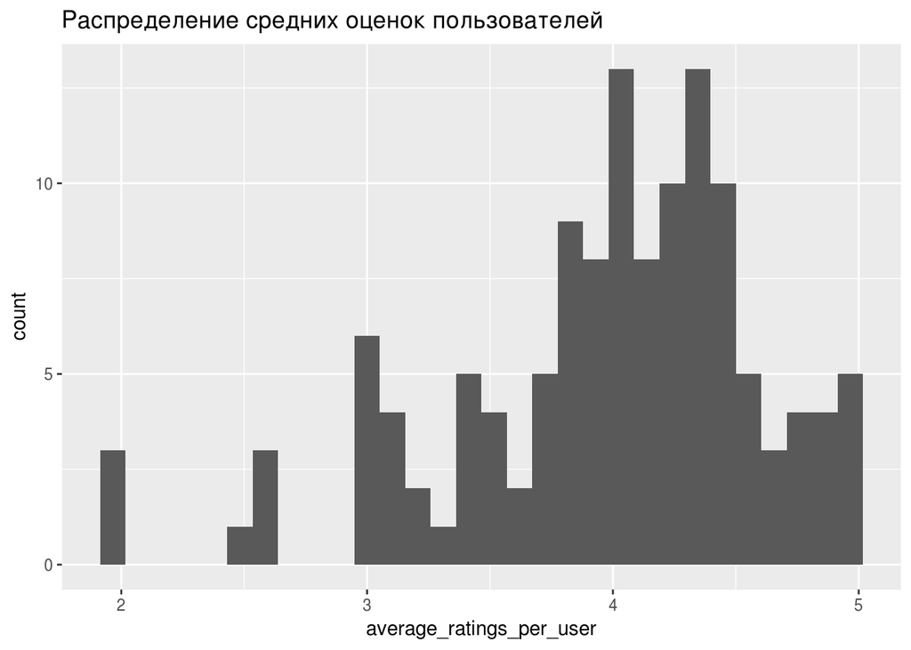

```r
average_ratings_per_user <- rowMeans(ratings_movies)
ggplot()+geom_histogram(aes(x=average_ratings_per_user)) +
ggtitle("Распределение средних оценок пользователей")
```

### Метод коллаборативной фильтрации

- вычислить похожесть всех пар фильмов
- для каждого фильма найти k наиболее похожих
- для каждого пользователя определить фильмы, наиболее близкие к тем, которые он оценил

Разделим данные на тестовую и обучающую выборки. На обучающей построим модель, для пользователей из тестовой будем рекомендовать фильмы.

```r
set.seed(100)
test_ind <- sample(1:nrow(ratings_movies), size = nrow(ratings_movies)*0.2)
recc_data_train <- ratings_movies[-test_ind, ]
recc_data_test <- ratings_movies[test_ind, ]
```

Возможны разные методы построения модели. Рассмотрим метод IBCF (“Recommender based on item-based collaborative filtering (real data).”)

Построим рекомендательную модель

```r
recc_model <- Recommender(data = recc_data_train, method = "IBCF",
parameter = list(k = 30))
recc_model
```

```
## Recommender of type 'IBCF' for 'realRatingMatrix'
## learned using 103 users.
```

Детали этой модели можно получить с помощью метода getModel(), например, матрицу схожести

```r
model_details <- getModel(recc_model)
model_details$description
```

```
## [1] "IBCF: Reduced similarity matrix"
```

```r
model_details$sim[1:5, 1:5]
```

```
## 5 x 5 sparse Matrix of class "dgCMatrix"
##            0767802470 0767802624 0767805267 076781956X 078321958X
## 0767802470  .          0.2813587  .         .                   .
## 0767802624  0.2813587  .          0.2427732 .                   .
## 0767805267  .          0.2427732  .         0.23826592          .
## 076781956X  .          .          0.2382659 .                   .
## 078321958X  .          .          .         0.01864367          .
```

Рекомендации

- для каждого пользователя извлекаются те фильмы, которые он оценил
- для каждого из фильмов находятся похожие фильмы
- затем фильмы упорядочиваются согласно весам, где вес каждой рекомендации (фильма) вычисляется на основе оценок пользователя и показателей схожести фильмов (взвешенная сумма)

```r
recc_predicted <- predict(object = recc_model, newdata = recc_data_test, n = 6)
recc_predicted
```

```
## Recommendations as 'topNList' with n = 6 for 25 users.
```

Посмотрим на результат

```r
str(recc_predicted)
```

```
## Formal class 'topNList' [package "recommenderlab"] with 4 slots
##   ..@ items     :List of 25
##   .. ..$ A2C5VLIJMDPWHI: int [1:6] 10 12 20 21 22 23
##   .. ..$ A216NLPTKDIUVU: int [1:6] 4 5 6 8 10 12
##   .. ..$ A35R8PJSEURHHF: int [1:6] 6 7 9 17 19 38
##   .. ..$ A17FLA8HQOFVIG: int [1:6] 38 66 81 87 132 133
##   .. ..$ A2WX1UESDOLXRE: int [1:6] 2 6 7 9 13 14
##   .. ..$ A2XOS0D485JSMM: int [1:6] 8 10 12 15 18 23
##   .. ..$ A9LAPV8XNKZVZ : int [1:6] 42 67 23 21 63 69
##   .. ..$ A2FBIF1FKBC193: int [1:6] 5 1 18 19 21 23
##   .. ..$ A328S9RN3U5M68: int [1:6] 95 18 50 49 29 37
##   .. ..$ A1LZVU5SRRM3VX: int [1:6] 9 12 22 26 33 38
##   .. ..$ A38QJ7JUUTVLKX: int [1:6] 12 15 21 23 24 32
##   .. ..$ ABN5K7K1TM1QA : int [1:6] 67 44 139 123 40 79
##   .. ..$ AYWSFRCIMOAYE : int [1:6] 17 37 7 44 15 106
##   .. ..$ A2GCHG6U8HTVIT: int [1:6] 9 14 16 20 21 23
##   .. ..$ A3MLO4GAD2O9DL: int [1:6] 31 4 114 19 125 20
##   .. ..$ A3956O40ZZYFMY: int [1:6] 10 11 16 17 19 20
##   .. ..$ A1NSMQIF1C2VCE: int [1:6] 27 99 46 91 23 44
##   .. ..$ AZCDCO6KK2T81 : int [1:6] 10 16 109 110 45 20
##   .. ..$ AHIK7BUXFRMT8 : int [1:6] 10 11 15 16 18 22
##   .. ..$ ANGH6401L9Y0T : int [1:6] 102 101 117 66 54 44
##   .. ..$ A2VD3CYOEMJ6SR: int [1:6] 13 19 22 23 24 39
##   .. ..$ A39CX0EE4BZCZC: int [1:6] 2 122 46 84 97 3
##   .. ..$ AEKFFH7E7WLI4 : int [1:6] 1 4 7 14 16 19
##   .. ..$ A3C6X0DAM87GN4: int [1:6] 9 41 46 39 6 110
##   .. ..$ A2EDZH51XHFA9B: int [1:6] 2 92 7 27 1 98
##   ..@ ratings   :List of 25
##   .. ..$ A2C5VLIJMDPWHI: num [1:6] 5 5 5 5 5 5
##   .. ..$ A216NLPTKDIUVU: num [1:6] 5 5 5 5 5 5
##   .. ..$ A35R8PJSEURHHF: num [1:6] 5 5 5 5 5 5
##   .. ..$ A17FLA8HQOFVIG: num [1:6] 5 5 5 5 5 5
##   .. ..$ A2WX1UESDOLXRE: num [1:6] 5 5 5 5 5 5
##   .. ..$ A2XOS0D485JSMM: num [1:6] 5 5 5 5 5 5
##   .. ..$ A9LAPV8XNKZVZ : num [1:6] 5 4.64 4.62 4.29 4.21 ...
##   .. ..$ A2FBIF1FKBC193: num [1:6] 5.41 5 5 5 5 ...
##   .. ..$ A328S9RN3U5M68: num [1:6] 4.93 4.92 4.91 4.89 4.89 ...
##   .. ..$ A1LZVU5SRRM3VX: num [1:6] 5 5 5 5 5 5
##   .. ..$ A38QJ7JUUTVLKX: num [1:6] 5 5 5 5 5 5
##   .. ..$ ABN5K7K1TM1QA : num [1:6] 5 4.76 4.72 4.66 4.65 ...
##   .. ..$ AYWSFRCIMOAYE : num [1:6] 4.39 4.05 4.01 3.99 3.82 ...
##   .. ..$ A2GCHG6U8HTVIT: num [1:6] 5 5 5 5 5 5
##   .. ..$ A3MLO4GAD2O9DL: num [1:6] 3.6 3.58 3.53 3.52 3.48 ...
##   .. ..$ A3956O40ZZYFMY: num [1:6] 5 5 5 5 5 5
##   .. ..$ A1NSMQIF1C2VCE: num [1:6] 5 5 4.67 4.61 4.56 ...
##   .. ..$ AZCDCO6KK2T81 : num [1:6] 5 5 5 5 4.83 ...
##   .. ..$ AHIK7BUXFRMT8 : num [1:6] 5 5 5 5 5 5
##   .. ..$ ANGH6401L9Y0T : num [1:6] 4.57 4.56 4.52 4.52 4.51 ...
##   .. ..$ A2VD3CYOEMJ6SR: num [1:6] 5 5 5 5 5 5
##   .. ..$ A39CX0EE4BZCZC: num [1:6] 4.7 4.69 4.67 4.66 4.66 ...
##   .. ..$ AEKFFH7E7WLI4 : num [1:6] 5 5 5 5 5 5
##   .. ..$ A3C6X0DAM87GN4: num [1:6] 4.81 4.61 4.54 4.51 4.47 ...
##   .. ..$ A2EDZH51XHFA9B: num [1:6] 4.17 4.04 4 3.95 3.91 ...
##   ..@ itemLabels: chr [1:139] "0767802470" "0767802624" "0767805267" "076781956X" ...
##   ..@ n         : int 6
```

Слоты (доступ через символ @)

- items – содержит индексы рекомендованных фильмов для каждого пользователя
- itemLabels – названия фильмов
- ratings – рейтинги рекомендаций
- n – число рекомендаций

Рекомендации для первого пользователя

```r
recc_user_1 <- recc_predicted@items[[1]]
recc_user_1
```

```
## [1] 10 12 20 21 22 23
```

Это результат в виде номер строк в матрице, вытащим id фильмов

```r
movies_user_1 <- recc_predicted@itemLabels[recc_user_1]
movies_user_1
```

```
## [1] "0788814664" "079070546X" "0792164903" "079283318X" "0792833260"
## [6] "0792841395"
```

А теперь посмотрим на названия. Функция `match` возвращает позицию, на которой элементы из первого параметра встретились во втором (см. `?match`)

```r
names_movies_user_1 <- jmeta$title[match(movies_user_1, jmeta$asin)]
names_movies_user_1
```

```
## [1] "Good Will Hunting"
## [2] "National Lampoon's Christmas Vacation "
## [3] "Sleepy Hollow"
## [4] "GoldenEye "
## [5] "Rain Man"
## [6] "The Killing"
```

### Схожесть не только по оценкам

Введем интересующие нас показатели по фильмам. Например,

- количество отзывов
- средняя оценка

```r
counts = j %>% group_by(asin) %>% summarize(reviews = n(), average = mean(overall))
```

- цена
- длина описания

```r
data = left_join(counts, jmeta, by = "asin")
data = as.data.frame(data)
data$length = str_length(data$description)
rownames(data) = data$title
data = select(data, -description, -title, -asin)
data = as.matrix(data)
```

Найдем схожесть по косинусному расстоянию

```r
library(lsa)
cosine(t(data[1:3,]))
```

```
##                               Mandie and the Secret Tunnel
## Mandie and the Secret Tunnel                     1.0000000
## Das Boot - The Director's Cut                    0.9997876
## Men in Black                                     0.6528922
##                               Das Boot - The Director's Cut Men in Black
## Mandie and the Secret Tunnel                      0.9997876     0.6528922
## Das Boot - The Director's Cut                     1.0000000     0.6511044
## Men in Black                                      0.6511044     1.0000000
```

```r
dist = cosine(t(data))
data[is.na(data)] = 0
dist = cosine(t(data))
tail(sort(dist["The Dark Knight ",]))
```

```
##             Scoop  The Illusionist    The Italian Job War of the Worlds
##         0.9999832         0.9999893         0.9999903         0.9999940
##           Monster  The Dark Knight
##         0.9999966         1.0000000
```

**Ваша очередь:**

1. Постройте рекомендательную систему на основе схожести между пользователями, а не между фильмами (метод UBCF вместо IBCF).
2. Придумайте свои характеристики фильмов или пользователей и сравните.